# Capstone Project Case study

By: Victor Chidimma Okafor

2022-06-16

[figure not shown]

Bellabeat logo

## About the Company

Urška Sršen and Sando Mur founded Bellabeat, a high-tech company that manufactures health-focused smart products. Sršen used her background as an artist to develop beautifully designed technology that informs and inspires women around the world. Collecting data on activity, sleep, stress, and reproductive health has allowed Bellabeat to empower women with knowledge about their own health and habits. Since it was founded in 2013, Bellabeat has grown rapidly and quickly positioned itself as a tech-driven wellness company for women. More on the website.

#### Business Task

- Analyze trends of smart device usage.
- Provide high-level content recommendation on marketing strategy for a Bellabeat product.

#### Key stakeholders

**Primary Stakehoders:**

- Urška Sršen: Bellabeat’s cofounder and Chief Creative Officer.
- Sando Mur: Mathematician and Bellabeat’s cofounder; key member of the Bellabeat executive team.

**Secondary Stakeholders:**

- Bellabeat marketing analytics team.

### Assigning new names to datasets

```r
dailyActivity<- (dailyActivity_merged)
dailyCalories<- (dailyCalories_merged)
dailyIntensities<- (dailyIntensities_merged)
dailySteps<- (dailySteps_merged)
dailySleep<- (sleepDay_merged)
intensities<- (hourlyIntensities_merged)
```

## Data Cleaning

I will start the initial process of data cleaning by finding the number of distinct customer Ids in the data set. This will help me check if it (number of Ids) corresponds with the information i have about the data set.

```r
n_distinct(dailyActivity$Id)
```

```
## [1] 33
```

```r
n_distinct(dailyCalories$Id)
```

```
## [1] 33
```

```r
n_distinct(dailyIntensities$Id)
```

```
## [1] 33
```

```r
n_distinct(dailySleep$Id)
```

```
## [1] 24
```

```r
n_distinct(dailySteps$Id)
```

```
## [1] 33
```

```r
n_distinct(intensities$Id)
```

```
## [1] 33
```

##### Result

This shows that dailyActivity, dailyCalories, dailyIntensities, intensities and dailySteps all have 33 distinct IDs. while dailySleep has 24 disntinct IDs.

#### Checking for duplicates

```r
sum(duplicated(dailyActivity))
```

```
## [1] 0
```

```r
sum(duplicated(dailyCalories))
```

```
## [1] 0
```

```r
sum(duplicated(dailyIntensities))
```

```
## [1] 0
```

```r
sum(duplicated(intensities))
```

```
## [1] 0
```

```r
sum(duplicated(dailySteps))
```

```
## [1] 0
```

```r
sum(duplicated(dailySleep))
```

```
## [1] 3
```

```r
sum(duplicated(intensities))
```

```
## [1] 0
```

```r
dailySleep<- dailySleep %>%
  distinct() %>%
  drop_na()
```

To verify that duplicates has been removed

```r
sum(duplicated(dailySleep))
```

```
## [1] 0
```

#### Catch a view of the cleaned data sets

```r
head(dailyActivity)
```

```
## # A tibble: 6 × 15
##        Id ActivityDate TotalSteps TotalDistance TrackerDistance LoggedActivitie…
##     <dbl> <chr>             <dbl>         <dbl>           <dbl>            <dbl>
## 1  1.50e9 4/12/2016         13162          8.5             8.5                 0
## 2  1.50e9 4/13/2016         10735          6.97            6.97                0
## 3  1.50e9 4/14/2016         10460          6.74            6.74                0
## 4  1.50e9 4/15/2016          9762          6.28            6.28                0
## 5  1.50e9 4/16/2016         12669          8.16            8.16                0
## 6  1.50e9 4/17/2016          9705          6.48            6.48                0
## # … with 9 more variables: VeryActiveDistance <dbl>,
## #   ModeratelyActiveDistance <dbl>, LightActiveDistance <dbl>,
## #   SedentaryActiveDistance <dbl>, VeryActiveMinutes <dbl>,
## #   FairlyActiveMinutes <dbl>, LightlyActiveMinutes <dbl>,
## #   SedentaryMinutes <dbl>, Calories <dbl>
```

```r
head(dailyCalories)
```

```
## # A tibble: 6 × 3
##           Id ActivityDay Calories
##        <dbl> <chr>          <dbl>
## 1 1503960366 4/12/2016       1985
## 2 1503960366 4/13/2016       1797
## 3 1503960366 4/14/2016       1776
## 4 1503960366 4/15/2016       1745
## 5 1503960366 4/16/2016       1863
## 6 1503960366 4/17/2016       1728
```

```r
head(dailyIntensities)
```

```
## # A tibble: 6 × 10
##           Id ActivityDay SedentaryMinutes LightlyActiveMinutes FairlyActiveMinu…
##        <dbl> <chr>                  <dbl>                <dbl>             <dbl>
## 1 1503960366 4/12/2016                728                  328                13
## 2 1503960366 4/13/2016                776                  217                19
## 3 1503960366 4/14/2016               1218                  181                11
## 4 1503960366 4/15/2016                726                  209                34
## 5 1503960366 4/16/2016                773                  221                10
## 6 1503960366 4/17/2016                539                  164                20
## # … with 5 more variables: VeryActiveMinutes <dbl>,
## #   SedentaryActiveDistance <dbl>, LightActiveDistance <dbl>,
## #   ModeratelyActiveDistance <dbl>, VeryActiveDistance <dbl>
```

```r
head(dailySleep)
```

```
## # A tibble: 6 × 5
##           Id SleepDay           TotalSleepRecor… TotalMinutesAsl… TotalTimeInBed
##        <dbl> <chr>                         <dbl>            <dbl>          <dbl>
## 1 1503960366 4/12/2016 12:00:0…                1              327            346
## 2 1503960366 4/13/2016 12:00:0…                2              384            407
## 3 1503960366 4/15/2016 12:00:0…                1              412            442
## 4 1503960366 4/16/2016 12:00:0…                2              340            367
## 5 1503960366 4/17/2016 12:00:0…                1              700            712
## 6 1503960366 4/19/2016 12:00:0…                1              304            320
```

```r
head(dailySteps)
```

```
## # A tibble: 6 × 3
##           Id ActivityDay StepTotal
##        <dbl> <chr>           <dbl>
## 1 1503960366 4/12/2016       13162
## 2 1503960366 4/13/2016       10735
## 3 1503960366 4/14/2016       10460
## 4 1503960366 4/15/2016        9762
## 5 1503960366 4/16/2016       12669
## 6 1503960366 4/17/2016        9705
```

```r
head(intensities)
```

```
## # A tibble: 6 × 4
##           Id ActivityHour          TotalIntensity AverageIntensity
##        <dbl> <chr>                          <dbl>            <dbl>
## 1 1503960366 4/12/2016 12:00:00 AM             20            0.333
## 2 1503960366 4/12/2016 1:00:00 AM               8            0.133
## 3 1503960366 4/12/2016 2:00:00 AM               7            0.117
## 4 1503960366 4/12/2016 3:00:00 AM               0            0
## 5 1503960366 4/12/2016 4:00:00 AM               0            0
## 6 1503960366 4/12/2016 5:00:00 AM               0            0
```

#### Formating

```r
dailyActivity <- dailyActivity %>%
  rename(date = ActivityDate) %>%
  mutate(date = as_date(date, format = "%m/%d/%Y"))

dailySleep <- dailySleep %>%
  rename(date = SleepDay) %>%
  mutate(date = as_date(date, format ="%m/%d/%Y %I:%M:%S %p" , tz=Sys.timezone()))
```

### Analysis and Visualization

We will first start by writing a code to gain high level information in the data.

```r
dailyActivity %>%
  select(TotalSteps,
         TotalDistance,
         SedentaryMinutes, Calories,
         VeryActiveMinutes,
         LightlyActiveMinutes) %>%
  summary()
```

```
##    TotalSteps    TotalDistance    SedentaryMinutes    Calories
##  Min.   :    0   Min.   : 0.000   Min.   :   0.0   Min.   :   0
##  1st Qu.: 3790   1st Qu.: 2.620   1st Qu.: 729.8   1st Qu.:1828
##  Median : 7406   Median : 5.245   Median :1057.5   Median :2134
##  Mean   : 7638   Mean   : 5.490   Mean   : 991.2   Mean   :2304
##  3rd Qu.:10727   3rd Qu.: 7.713   3rd Qu.:1229.5   3rd Qu.:2793
##  Max.   :36019   Max.   :28.030   Max.   :1440.0   Max.   :4900
##  VeryActiveMinutes LightlyActiveMinutes
##  Min.   :  0.00    Min.   :  0.0
##  1st Qu.:  0.00    1st Qu.:127.0
##  Median :  4.00    Median :199.0
##  Mean   : 21.16    Mean   :192.8
##  3rd Qu.: 32.00    3rd Qu.:264.0
##  Max.   :210.00    Max.   :518.0
```

```r
dailyCalories %>%
  select(Calories) %>%
  summary()
```

```
##     Calories
##  Min.   :   0
##  1st Qu.:1828
##  Median :2134
##  Mean   :2304
##  3rd Qu.:2793
##  Max.   :4900
```

```r
dailyIntensities %>%
  select(VeryActiveMinutes,
         SedentaryMinutes,
         VeryActiveDistance) %>%
  summary()
```

```
##  VeryActiveMinutes SedentaryMinutes VeryActiveDistance
##  Min.   :  0.00    Min.   :   0.0   Min.   : 0.000
##  1st Qu.:  0.00    1st Qu.: 729.8   1st Qu.: 0.000
##  Median :  4.00    Median :1057.5   Median : 0.210
##  Mean   : 21.16    Mean   : 991.2   Mean   : 1.503
##  3rd Qu.: 32.00    3rd Qu.:1229.5   3rd Qu.: 2.053
##  Max.   :210.00    Max.   :1440.0   Max.   :21.920
```

```r
dailySteps %>%
  select(StepTotal) %>%
  summary()
```

```
##    StepTotal
##  Min.   :    0
##  1st Qu.: 3790
##  Median : 7406
##  Mean   : 7638
##  3rd Qu.:10727
##  Max.   :36019
```

```r
dailySleep %>%
  select(TotalTimeInBed,
         TotalMinutesAsleep,
         TotalSleepRecords) %>%
  summary()
```

```
##  TotalTimeInBed  TotalMinutesAsleep TotalSleepRecords
##  Min.   : 61.0   Min.   : 58.0      Min.   :1.00
##  1st Qu.:403.8   1st Qu.:361.0      1st Qu.:1.00
##  Median :463.0   Median :432.5      Median :1.00
##  Mean   :458.5   Mean   :419.2      Mean   :1.12
##  3rd Qu.:526.0   3rd Qu.:490.0      3rd Qu.:1.00
##  Max.   :961.0   Max.   :796.0      Max.   :3.00
```

#### Result

This summary of four data sets (dailyActivties, dailyIntensities, dailyCalories and dailySteps) show a lot of correspondence in terms of average, maximum and minimum input of selected variables . The only data set with marked difference is the dailySleep data set which does not have corresponding variables except for date and Id.

#### Summary

The participants were largely inactive. Which could mean that they are either really aged or white collar workers, but a visualization could help us prove or disprove this theory.

**Merging datasets** we will inner join the dailyActivity and dailySleep data frames. The combination of both tables contain a lot information which will be easy to access from the new table.

```r
dailyActivitySleep <- merge(dailyActivity, dailySleep, by=c("Id", "date"))
glimpse(dailyActivitySleep)
```

```
## Rows: 410
## Columns: 18
## $ Id                       <dbl> 1503960366, 1503960366, 1503960366, 150396036…
## $ date                     <date> 2016-04-12, 2016-04-13, 2016-04-15, 2016-04-…
## $ TotalSteps               <dbl> 13162, 10735, 9762, 12669, 9705, 15506, 10544…
## $ TotalDistance            <dbl> 8.50, 6.97, 6.28, 8.16, 6.48, 9.88, 6.68, 6.3…
## $ TrackerDistance          <dbl> 8.50, 6.97, 6.28, 8.16, 6.48, 9.88, 6.68, 6.3…
## $ LoggedActivitiesDistance <dbl> 0, 0, 0, 0, 0, 0, 0, 0, 0, 0, 0, 0, 0, 0, 0, …
## $ VeryActiveDistance       <dbl> 1.88, 1.57, 2.14, 2.71, 3.19, 3.53, 1.96, 1.3…
## $ ModeratelyActiveDistance <dbl> 0.55, 0.69, 1.26, 0.41, 0.78, 1.32, 0.48, 0.3…
## $ LightActiveDistance      <dbl> 6.06, 4.71, 2.83, 5.04, 2.51, 5.03, 4.24, 4.6…
## $ SedentaryActiveDistance  <dbl> 0, 0, 0, 0, 0, 0, 0, 0, 0, 0, 0, 0, 0, 0, 0, …
## $ VeryActiveMinutes        <dbl> 25, 21, 29, 36, 38, 50, 28, 19, 41, 39, 73, 3…
## $ FairlyActiveMinutes      <dbl> 13, 19, 34, 10, 20, 31, 12, 8, 21, 5, 14, 23,…
## $ LightlyActiveMinutes     <dbl> 328, 217, 209, 221, 164, 264, 205, 211, 262, …
## $ SedentaryMinutes         <dbl> 728, 776, 726, 773, 539, 775, 818, 838, 732, …
## $ Calories                 <dbl> 1985, 1797, 1745, 1863, 1728, 2035, 1786, 177…
## $ TotalSleepRecords        <dbl> 1, 2, 1, 2, 1, 1, 1, 1, 1, 1, 1, 1, 1, 1, 1, …
## $ TotalMinutesAsleep       <dbl> 327, 384, 412, 340, 700, 304, 360, 325, 361, …
## $ TotalTimeInBed           <dbl> 346, 407, 442, 367, 712, 320, 377, 364, 384, …
```

```r
head(dailyActivitySleep)
```

```
##           Id       date TotalSteps TotalDistance TrackerDistance
## 1 1503960366 2016-04-12      13162          8.50            8.50
## 2 1503960366 2016-04-13      10735          6.97            6.97
## 3 1503960366 2016-04-15       9762          6.28            6.28
## 4 1503960366 2016-04-16      12669          8.16            8.16
## 5 1503960366 2016-04-17       9705          6.48            6.48
## 6 1503960366 2016-04-19      15506          9.88            9.88
##   LoggedActivitiesDistance VeryActiveDistance ModeratelyActiveDistance
## 1                        0               1.88                     0.55
## 2                        0               1.57                     0.69
## 3                        0               2.14                     1.26
## 4                        0               2.71                     0.41
## 5                        0               3.19                     0.78
## 6                        0               3.53                     1.32
##   LightActiveDistance SedentaryActiveDistance VeryActiveMinutes
```

[output cut: 20 more lines]

```r
dailyAverage <- dailyActivitySleep %>%
  group_by(Id) %>%
  summarise(mean_daily_steps=mean(TotalSteps), mean_daily_calories=mean(Calories), mean_daily_sleep=mean(TotalMinutesAsleep))

head(dailyAverage)
```

```
## # A tibble: 6 × 4
##           Id mean_daily_steps mean_daily_calories mean_daily_sleep
##        <dbl>            <dbl>               <dbl>            <dbl>
## 1 1503960366           12406.               1872.             360.
## 2 1644430081            7968.               2978.             294
## 3 1844505072            3477                1676.             652
## 4 1927972279            1490                2316.             417
## 5 2026352035            5619.               1541.             506.
## 6 2320127002            5079                1804               61
```

```r
userType<- dailyAverage %>%
  mutate(userActivity=case_when(
    mean_daily_steps<5000 ~ "Sedentary",
    mean_daily_steps>=5000 & mean_daily_steps < 7500 ~ "Lightly Active",
    mean_daily_steps>=7501 & mean_daily_steps < 10000 ~ "Moderately Active",
    mean_daily_steps>=10001 ~ "Very Active"
    ))

head(userType)
```

```
## # A tibble: 6 × 5
##           Id mean_daily_steps mean_daily_calories mean_daily_sleep userActivity
##        <dbl>            <dbl>               <dbl>            <dbl> <chr>
## 1 1503960366           12406.               1872.             360. Very Active
## 2 1644430081            7968.               2978.             294  Moderately A…
## 3 1844505072            3477                1676.             652  Sedentary
## 4 1927972279            1490                2316.             417  Sedentary
## 5 2026352035            5619.               1541.             506. Lightly Acti…
## 6 2320127002            5079                1804               61  Lightly Acti…
```

We will add a new column to our table. The new column will show the percentage of participants by the level of activity which will help us understand the data better on a visualization.

```r
userTypePercent<- userType %>%
  group_by(userActivity) %>%
   summarise(total = n()) %>%
  mutate(totals = sum(total)) %>%
  group_by(userActivity) %>%
  summarise(percentTotal = total / totals) %>%
  mutate(percentage = scales::percent(percentTotal))

head(userTypePercent) %>% arrange(desc(percentage))
```

```
## # A tibble: 4 × 3
##   userActivity      percentTotal percentage
##   <chr>                    <dbl> <chr>
## 1 Moderately Active        0.375 38%
## 2 Lightly Active           0.208 21%
## 3 Sedentary                0.208 21%
## 4 Very Active              0.208 21%
```

## Visualizations

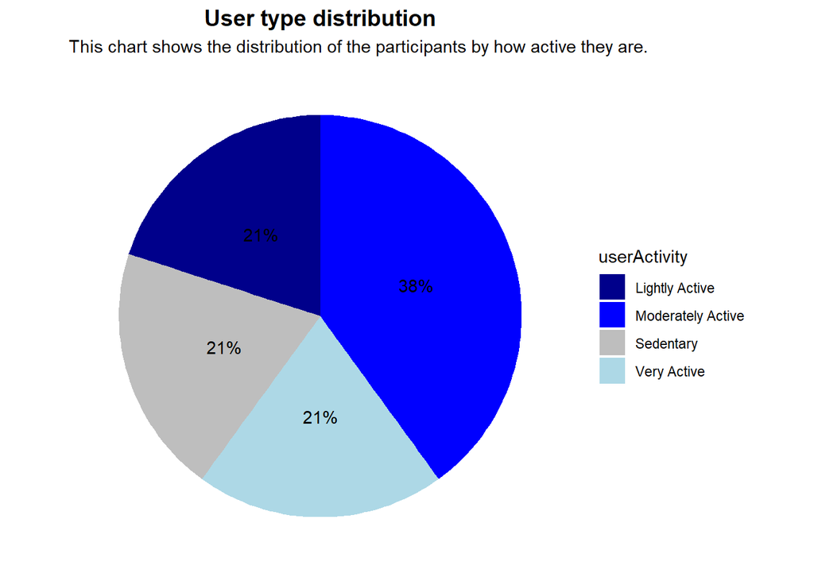

```r
userTypePercent %>%
  ggplot(aes(x="", y=percentage, fill=userActivity))+
  geom_bar(stat = "identity", width = 1)+
  coord_polar(theta = "y",  start=0)+
  theme_minimal()+
  theme(axis.title.x = element_blank(),
        axis.title.y = element_blank(),
        panel.border = element_blank(),
        panel.grid = element_blank(),
        axis.ticks = element_blank(),
        axis.text.x = element_blank(),
        plot.title = element_text(hjust = 0.5, size=14, face = "bold"))+
  scale_fill_manual(values = c("dark blue", "blue", "grey", "light blue"))+
  geom_text(aes(label = percentage),
            position = position_stack(vjust = 0.5))+
  labs(title = "User type distribution", subtitle = "This chart shows the distribution of the participants by how active they are." )
```

#### Observation

The chart above shows the activity of participants. Only 21% of the participants of this evaluation are very active. The other activity levels ranging from sedentary to moderately active take up the other 79% of the users.

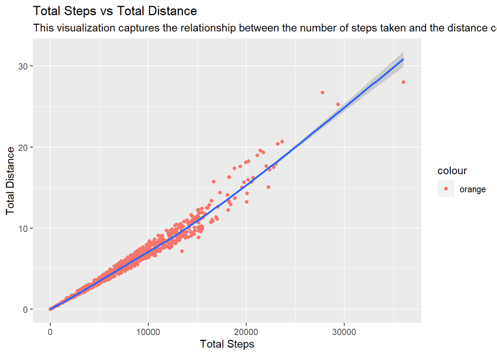

```r
ggplot(data = dailyActivity)+
  geom_point(mapping = aes(x=TotalSteps, y=TotalDistance, color ="orange"))+
  geom_smooth(mapping = aes(x=TotalSteps, y=TotalDistance))+
  labs(title = "Total Steps vs Total Distance", subtitle = "This visualization captures the relationship between the number of steps taken and the distance covered.", x="Total Steps", y="Total Distance")
```

#### Observation

It can be observed from the above graph that there is a positive relationship between steps and distance.

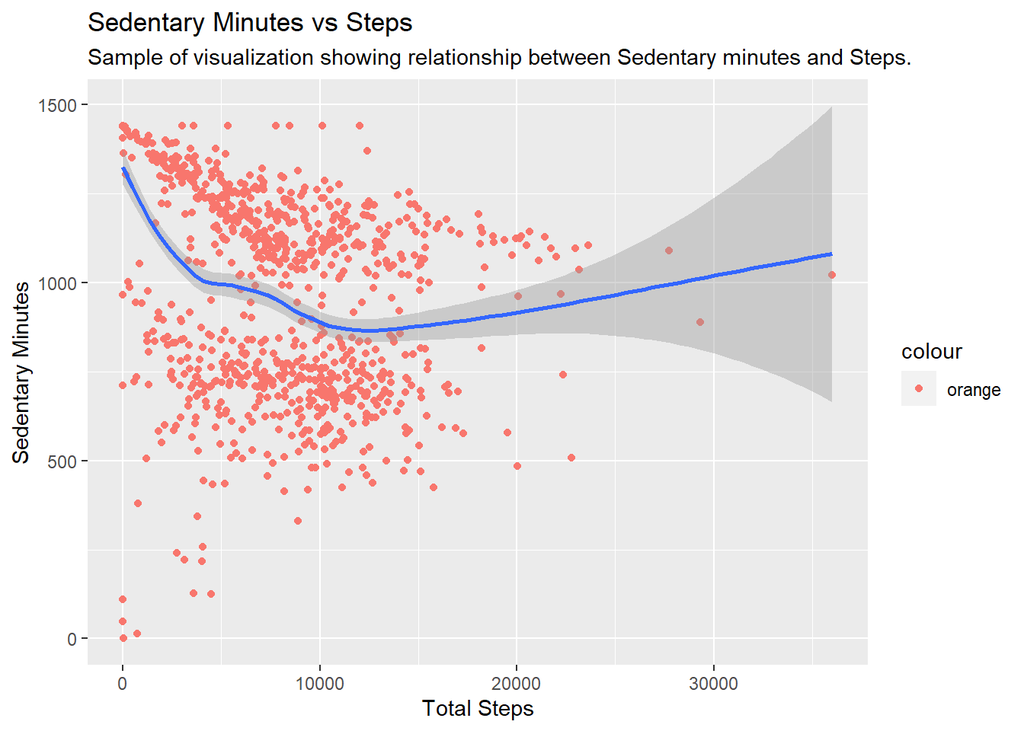

```r
ggplot(data = dailyActivity)+
  geom_point(mapping = aes(x=TotalSteps, y=SedentaryMinutes, color='orange'))+
  geom_smooth(mapping = aes(x=TotalSteps, y=SedentaryMinutes))+
  labs(title='Sedentary Minutes vs Steps', subtitle = "Sample of visualization showing relationship between Sedentary minutes and Steps.", x="Total Steps", y="Sedentary Minutes")
```

### Observation

The graph shows an inverse relationship between the number of steps taken and the sedentary minutes. This actively explains that participants that are sedentary are considered inactive.

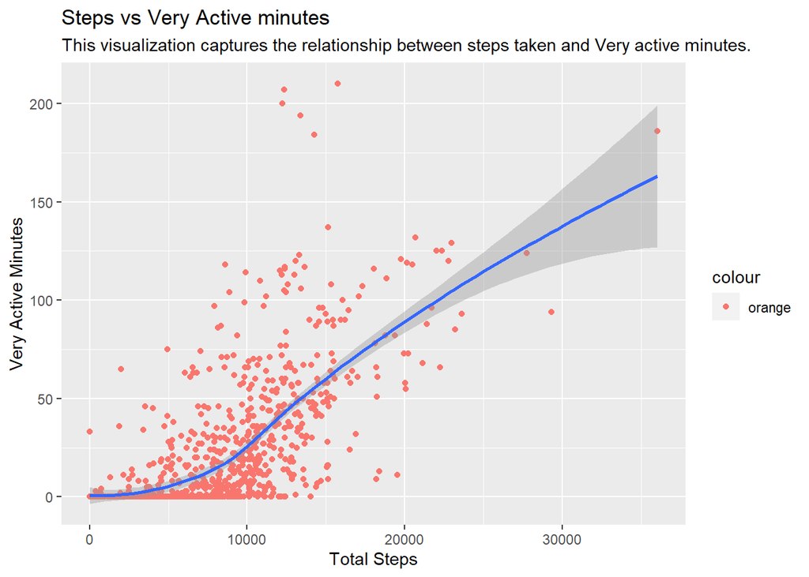

```r
ggplot(data = dailyActivity)+
  geom_point(mapping = aes(x=TotalSteps, y=VeryActiveMinutes, color="orange"))+
   geom_smooth(mapping = aes(x=TotalSteps, y=VeryActiveMinutes))+
  labs(title = "Steps vs Very Active minutes", subtitle = "This visualization captures the relationship between steps taken and Very active minutes.", x="Total Steps", y="Very Active Minutes")
```

#### Obesrvation

The visualization above shows a direct relationship between movement and activity. The visualization suggests that a moving person is an active person. The next visualization will help explain what this visualization indicates better.

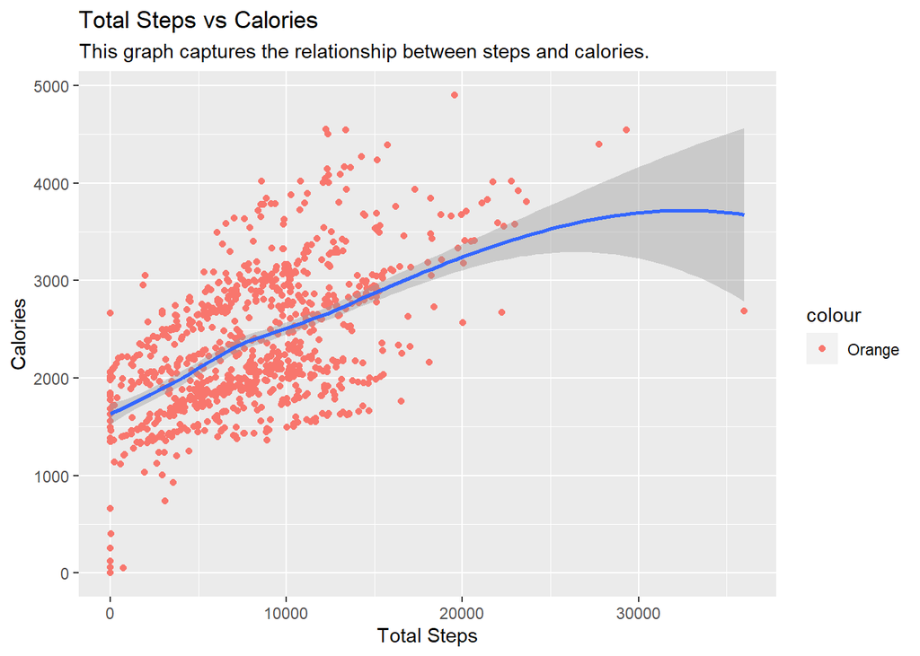

```r
ggplot(data = dailyActivity)+
  geom_point(mapping = aes(x=TotalSteps, y=Calories, color="Orange"))+
  geom_smooth(mapping = aes(x=TotalSteps, y=Calories))+
  labs(title = "Total Steps vs Calories", subtitle = "This graph captures the relationship between steps and calories.", x="Total Steps", Y="Calories")
```

#### Observation

The relationship between steps and calories burned is also positive.This explains that participants that who move around more frequently have an higher chance of burning calories which in turn keeps them healthy.

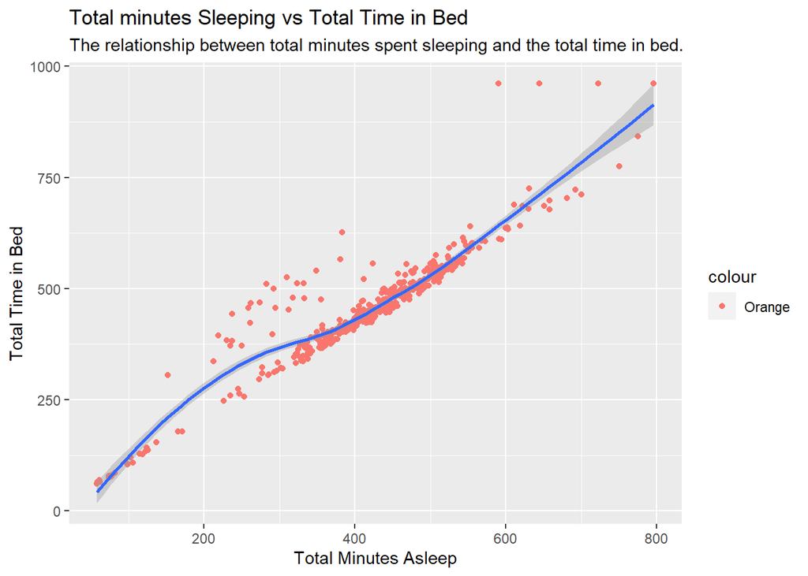

```r
ggplot(data = dailySleep)+
  geom_point(mapping = aes(x=TotalMinutesAsleep, y=TotalTimeInBed, color = "Orange"))+
  geom_smooth(mapping = aes(x=TotalMinutesAsleep, y=TotalTimeInBed,))+
  labs(title = "Total minutes Sleeping vs Total Time in Bed", subtitle = "The relationship between total minutes spent sleeping and the total time in bed.", x="Total Minutes Asleep", y="Total Time in Bed")
```

#### Observation

This graph shows a positive relationship between total time in bed and total minutes asleep. This is an indication that participants bed times are usually spent sleeping mostly.

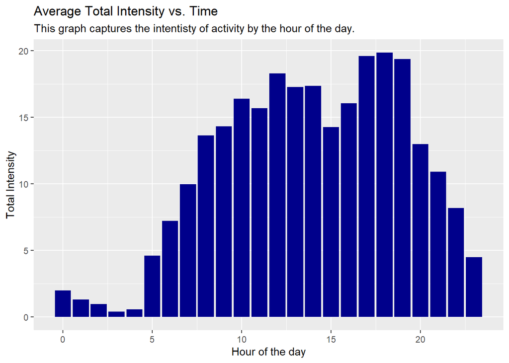

```r
 intensities<- hourlyIntensities_merged

 intensities$ActivityHour=as.POSIXct(intensities$ActivityHour, format="%m/%d/%Y %I:%M:%S %p", tz=Sys.timezone())
 intensities$time <- format(intensities$ActivityHour, format = "%H:%M:%S")
 intensities$date <- format(intensities$ActivityHour, format = "%m/%d/%y")

 intensity <- hourlyIntensities_merged %>%
   group_by(time(ActivityHour)) %>%
   drop_na() %>%
   summarise(mean_int = mean(TotalIntensity))
  ggplot(data = intensities, aes(x=hour(ActivityHour), y=TotalIntensity/1000))+
   geom_bar(stat = "identity", fill="dark blue")+
    labs(title="Average Total Intensity vs. Time", subtitle = "This graph captures the intentisty of activity by the hour of the day.", x="Hour of the day", y="Total Intensity")
```

## Summary and recommendations for Bellabeat membership:

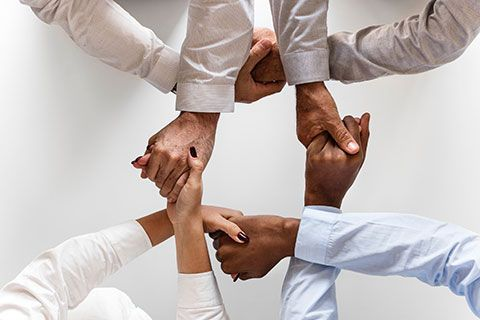

Membership

What is Bellabeat membership?

Bellabeat also offers a subscription-based membership program for users. Membership gives users 24/7 access to fully personalized guidance on nutrition, activity, sleep, health and beauty, and mindfulness based on their lifestyle and goals.

### summary

The trend from this data evaluation shows that these participants are interested in their health markers. This is the reason for their purchase of a smart device. From the data available, most of the participants (24 0f 33) put on their smart device even in bed.

**Who are our target audience?**

White Collar office workers who are too busy to visit their doctors regularly.

### Recommendations

- Our customers for Bellabeat membership should have their health markers monitored 24/7 and should be marketed as such.
- Our customers should be able to know that its not enough to monitor your body, but also to have a professional help you interpret your health data.
- Our marketing team should emphasize the personalized health tips that would be made available to our customers.
- Our marketing team should also explain that we are able to cater for users with other underlying health issues at no extra cost.
- Our marketing team should also focus on helping our customers know that we can recommend other exciting ways to keep fit.

Thank You. My first R project actually.